# Data Analysis

# Supplement

There is generally no evidence for the over-dispersion in the LRR values at individual elevations.

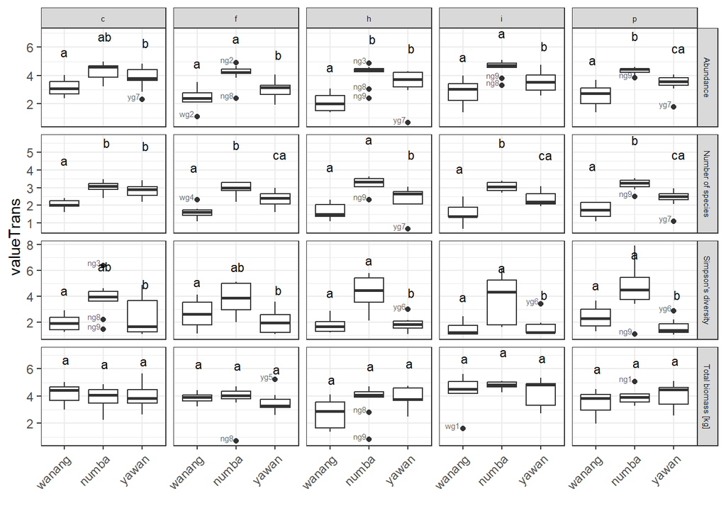

Figure S1. Median, 1st, 2nd quadrilles, 1.5 IRQ distance, and outliers (labeled) for logarithm of biomass, richness diversity, and density at three studied locations/elevations. Letters indicate statisitcal differences at the $lpha$ = 0.05 level from the post hos Tukey test.

**Table S1**. Test results for over-dispersion all descriptors at three studied elevations.

| testType | statName | testStat | pVal | treatmentCode | caselabel |
| --- | --- | --- | --- | --- | --- |
| Levene Test | F-value | 0.12 | 0.89 | f | biomass |
| Bartlett Test | Bartlett’s K-squared | 0.28 | 0.87 | f | biomass |
| homogenous anova | F-value | 1.63 | 0.21 | f | biomass |
| Levene Test | F-value | 0.66 | 0.53 | i | biomass |
| Bartlett Test | Bartlett’s K-squared | 1.99 | 0.37 | i | biomass |
| homogenous anova | F-value | 2.08 | 0.13 | i | biomass |
| Levene Test | F-value | 1.36 | 0.28 | p | biomass |
| Bartlett Test | Bartlett’s K-squared | 1.55 | 0.46 | p | biomass |
| homogenous anova | F-value | 0.91 | 0.46 | p | biomass |
| Levene Test | F-value | 0.09 | 0.92 | h | biomass |
| Bartlett Test | Bartlett’s K-squared | 0.18 | 0.92 | h | biomass |
| homogenous anova | F-value | 5.33 | 0.01 | h | biomass |
| Levene Test | F-value | 0.04 | 0.96 | f | diversity |
| Bartlett Test | Bartlett’s K-squared | 0.73 | 0.69 | f | diversity |
| homogenous anova | F-value | 0.72 | 0.55 | f | diversity |
| Levene Test | F-value | 1.90 | 0.17 | i | diversity |
| Bartlett Test | Bartlett’s K-squared | 5.89 | 0.05 | i | diversity |
| homogenous anova | F-value | 2.43 | 0.09 | i | diversity |
| Levene Test | F-value | 0.00 | 1.00 | p | diversity |
| Bartlett Test | Bartlett’s K-squared | 0.16 | 0.92 | p | diversity |
| homogenous anova | F-value | 2.15 | 0.12 | p | diversity |
| Levene Test | F-value | 0.02 | 0.98 | h | diversity |
| Bartlett Test | Bartlett’s K-squared | 0.31 | 0.86 | h | diversity |
| homogenous anova | F-value | 0.81 | 0.50 | h | diversity |
| Levene Test | F-value | 0.95 | 0.40 | f | richness |
| Bartlett Test | Bartlett’s K-squared | 0.13 | 0.94 | f | richness |
| homogenous anova | F-value | 7.93 | 0.00 | f | richness |
| Levene Test | F-value | 1.52 | 0.24 | i | richness |
| Bartlett Test | Bartlett’s K-squared | 4.38 | 0.11 | i | richness |
| homogenous anova | F-value | 4.65 | 0.01 | i | richness |
| Levene Test | F-value | 0.74 | 0.49 | p | richness |
| Bartlett Test | Bartlett’s K-squared | 1.83 | 0.40 | p | richness |
| homogenous anova | F-value | 6.72 | 0.00 | p | richness |
| Levene Test | F-value | 0.47 | 0.63 | h | richness |
| Bartlett Test | Bartlett’s K-squared | 1.63 | 0.44 | h | richness |
| homogenous anova | F-value | 6.19 | 0.00 | h | richness |
| Levene Test | F-value | 2.96 | 0.07 | f | density |
| Bartlett Test | Bartlett’s K-squared | 3.98 | 0.14 | f | density |
| homogenous anova | F-value | 5.87 | 0.00 | f | density |
| Levene Test | F-value | 1.51 | 0.24 | i | density |
| Bartlett Test | Bartlett’s K-squared | 5.68 | 0.06 | i | density |
| homogenous anova | F-value | 1.01 | 0.41 | i | density |
| Levene Test | F-value | 4.66 | 0.02 | p | density |
| Bartlett Test | Bartlett’s K-squared | 3.50 | 0.17 | p | density |
| non-homogenous anova | F-value | 2.26 | 0.11 | p | density |
| Levene Test | F-value | 0.55 | 0.59 | h | density |
| Bartlett Test | Bartlett’s K-squared | 0.91 | 0.63 | h | density |
| homogenous anova | F-value | 5.67 | 0.01 | h | density |

Only woody stem density for the predator exclusion showed some evidence of over-dispersion. Including this in statistical model (using *varIdent(form = ~1|site)* as weights in the GLS function) showed significant difference of LRR in Yawan, that was not observed for LM model.

[figure not shown]

Figure S1. Median, 1st, 2nd quadrilles, 1.5 IRQ distance, and outliers (labeled) for logarithm of biomass, richness diversity, and density at three studied locations/elevations. Letters indicate statisitcal differences at the $lpha$ = 0.05 level from the post hos Tukey test.

**Table S2**. Two models testing difference of LRR of predator exclosures from zero at each elevation. General Least Squares assumes over-dispersion in the data

| Estimate | Standard.Error | T.value | P.value | Site | Model |
| --- | --- | --- | --- | --- | --- |
| 0.56 | 0.27 | 2.06 | 0.05 | Wanang | LM |
| -0.06 | 0.22 | -0.27 | 0.79 | Numba | LM |
| 0.38 | 0.22 | 1.71 | 0.10 | Yawan | LM |
| 0.56 | 0.40 | 1.38 | 0.18 | Wanang | GLS |
| -0.06 | 0.17 | -0.34 | 0.74 | Numba | GLS |
| 0.38 | 0.17 | 2.18 | 0.04 | Yawan | GLS |